# Statistical inference with the GSS data

## Setup

### Load packages

```r
library(ggplot2)
library(dplyr)
library(statsr)
library(knitr)
```

### Load data

```r
load("gss.Rdata")
```

## Part 1: Data

With the purpose to monitor and explain trends in residents’ behaviors, General Social Survey(GSS) has studied the growing complexity of American society for over four decades. It is the only full-probabilty, personal interview survey currently being conducted in US. Each survey from 1972 to 2004 was an independently drawn sample of English-speaking persons 18 years of age or over, living in non-institutional arrangements within the United States. Block quota sampling was used in 1972, 1973, and 1974 surveys. Full probability sampling was employed in the 1977-1980, 1982-1991, 1993-1998, 2000-2016 surveys.

Since the responsors are draw randomly countrywise and the sample size for each year never exceed 10% of the US population, thus we can consider responsors are independent and generalize to the US population.

However GSS is an observational study without random assignment to study groups, so the relationship from the data may only indication association but not causation.

As for the bias of the survey, before 2006 the GSS only sampled the English speaking population and over a dozen languages are excluded. This could impact on the data collection distribution as US is a country with high diversity. Also the survey interview is conducted by personal interview which take over an hour to complete, volunteers might represent for the people who desire to answer the survey questions and provide response bias.

## Part 2: Research question

My research topic is about the proportion trend of people that have no child. Global population aging is becoming a more and more serious problem during the prevous decades. Counties all over the world, such as Japan, Italy and France, are facing the huge challange bring by low birth rate. This research want to look into the proportion of the responsors older than 30 and have no child and compare the difference between last two decades.

## Part 3: Exploratory data analysis

First, let’s pull out and count the responses from volunteers older than 30 and have no child. And the following barplot shows the count by years.

```r
gss %>%
  subset(age >= 30 & childs == 0) -> no_child
dim(no_child)[1]
```

```
## [1] 8214
```

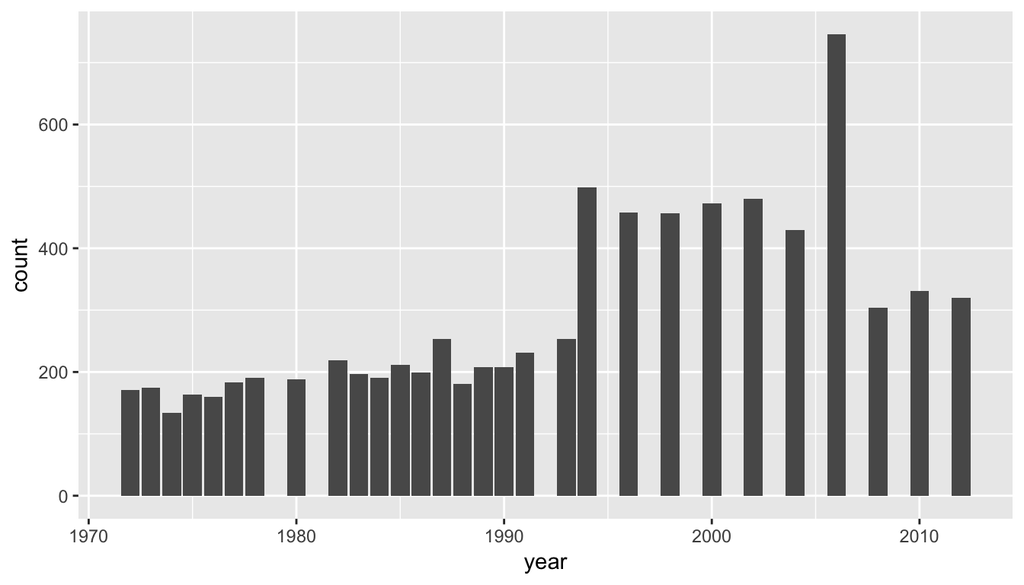

```r
ggplot(no_child, aes(x=year))+geom_bar()
```

Then we calculate the proportion by devided the total responses number and result is group by years and showing in the following table.

```r
gss %>%
  subset(age >= 30) %>%
  group_by(year) %>%
  summarise(total_res_over_30 = n(), no_child = length(childs[childs == 0]),
            proportion = no_child/total_res_over_30) ->
  no_child_prop

kable(no_child_prop[1:5,],digits = 4)
```

| year | total_res_over_30 | no_child | proportion |
| --- | --- | --- | --- |
| 1972 | 1208 | 177 | 0.1465 |
| 1973 | 1117 | 174 | 0.1558 |
| 1974 | 1098 | 138 | 0.1257 |
| 1975 | 1080 | 167 | 0.1546 |
| 1976 | 1105 | 161 | 0.1457 |

Then we plot the time trend of the proportion We can see the rate is keep climbing up since 1975 and create a peak at 2002. After 2002, the rate is start going down. We are going to compare the average proportion in 1994-2002 and 2004-2012.

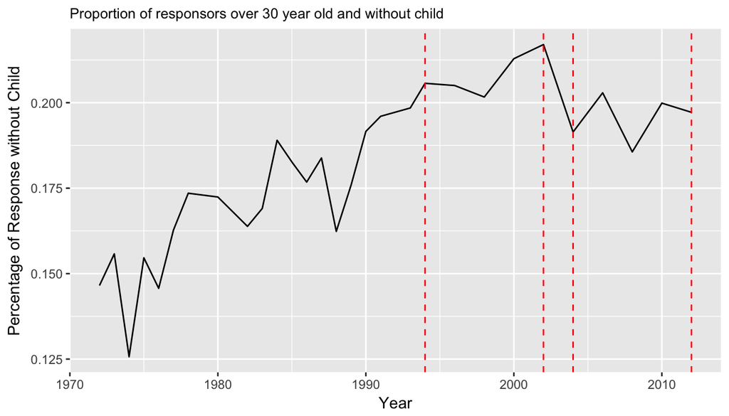

```r
ggplot(no_child_prop, aes(year,proportion)) +
  geom_line()+
  labs(x = "Year", y = "Percentage of Response without Child",subtitle = "Proportion of responsors over 30 year old and without child")+
  geom_vline(xintercept = c(1994,2002,2004,2012),colour = "red", linetype = 2)
```

```r
no_child_prop %>%
  subset(year >= 1994 & year <= 2002) %>%
  summarise(year = "1994-2002", no_child = sum(no_child), total = sum(total_res_over_30), prop = no_child/total) ->
  summary_table

no_child_prop %>%
  subset(year >= 2004 & year <= 2012) %>%
  summarise(year = "2004-2012", no_child = sum(no_child), total = sum(total_res_over_30), prop = no_child/total) %>%
  rbind(summary_table) %>%
  kable()
```

| year | no_child | total | prop |
| --- | --- | --- | --- |
| 2004-2012 | 2152 | 10946 | 0.1966015 |
| 1994-2002 | 2410 | 11567 | 0.2083513 |

## Part 4: Inference

For the statistical inference part, let’s do the hypothesis testing first. We are testing if the proportion of people have no child over 30 is different from period 1994-2002 than that in 2004-2012. The null hypothesis and alternate hypothesis is define as following:
$$H_0: p_{2004-2012}-p_{1994-2002}=0$$
$$H_0: p_{2004-2012}-p_{1994-2002}\neq0$$

Independence condition: The responsors are randomly selected from the US and no relation between among this survey time period, so the sample are both independ within groups and between groups. And the sample size are all smaller than the 10% of poplulation. So the independence condition is meet.

In order to check the sample size/skew condition, we need to calculate the estimated pooled proportion first. Multiple the pooled proportion with total sample size and all result are pass 10, so we can assume that the sampling distribution of the difference between two proportion is nearly normal

```r
no_child_prop[which(no_child_prop$year>=1994),] %>%
  summarise(pool = sum(no_child)/sum(total_res_over_30), s1 = pool*10946, s2 = (1-pool)*10946,
            s3 = pool*11567, s4 = (1-pool)*11567) %>%
  kable()
```

| pool | s1 | s2 | s3 | s4 |
| --- | --- | --- | --- | --- |
| 0.2026385 | 2218.081 | 8727.919 | 2343.919 | 9223.081 |

Point estimation and the SE is calculate as:
$$SE = \sqrt{\frac{\hat{p}_{poll}*(1-\hat{p}_{poll})}{total_{1994}}+\frac{\hat{p}_{poll}*(1-\hat{p}_{poll})}{total_{2004}}}=\sqrt{\frac{0.203*0.797}{11567}+\frac{0.203*0.797}{10946}}\approx0.00536$$
$$\hat{p}_{2004}-\hat{p}_{1994}=0.197-0.208=-0.011$$
The Z score and p-value is:
$$Z = \frac{-0.011-0}{0.00536}=-2.052$$
$$p-value = P(|Z| > 2.052)\approx0.0402$$
Thus, at 5% significant level, we reject the null hypothesis and conclude that the two proportion are different. We can also calculate a 95% confidence interval as:
$$\begin{eqnarray}
(\hat{p}_{2004}-\hat{p}_{1994})\pm Z^* \times SE &=& (0.197-0.208)\pm1.96*\sqrt{\frac{0.197*0.803}{10946}+\frac{0.208*0.792}{11567}}\\
&=& -0.011\pm1.96*0.00536 \\
&=& -0.011\pm0.0105 \\
&=& (-0.0215, -0.0005)
\end{eqnarray}$$
Since 0 is also not include in this interval, we can draw the same conclusion as the above hypothesis test.

# Result

From the hypothesis testing and the 95% confidence interval we can make conclustion that the rate of people that have no child and pass 30 year old is different in period of 1994 to 2002 from 2004 to 2012.

However the p-value is really close to 0.05 and the confidence interval is also close to 0, we cannot say it is a big difference.